# Final project

Elena Novikova

4/27/2020

CHSItable

| x |
| --- |
| Community Health Status Indicators (CHSI) to Combat Obesity, Heart Disease and Cancer |
| Metadata Updated: February 26, 2020 |
| Community Health Status Indicators (CHSI) to combat obesity, heart disease, and cancer are major components of the Community Health Data Initiative. This dataset provides key health indicators for loc… |

Peer Counties

x

County Health Rankings and Roadmaps and CDC’s Community Health Status Indicators (CHSI) have teamed up to offer an enhanced peer county comparison feature. This excel file provides information on the groups of counties that could be considered peers based on key demographic, social, and economic indicators. To utilize this feature, please locate your county (by county name or FIPS code) in the second tab of this file. The number in the “Peer County Group” column indicates the peer cluster for your county. To learn about others in this peer county group, you can sort or filter the spreadsheet for other counties in this group. Once you have identified the counties in your peer group, you can use the CHR&R compare counties feature to explore the health factors and outcomes across counties in your peer group.

Output Excel file County_FIPS.xlsx contains FIPS codes without missing zeros.

I am a resident of Passaic county, NJ. Let’s find what Strata my county belongs to, find Peer counties in this Strata, and count how many Peer counties are there:

```
## [1] "Passaic county, NJ belongs to strata 9"
```

Peer counties in Strata 9, a total of 34 counties

| FIPS | PeerCountyGroup | County | State |
| --- | --- | --- | --- |
| 06069 | 9 | San Benito County | California |
| 06071 | 9 | San Bernardino County | California |
| 06113 | 9 | Yolo County | California |
| 08001 | 9 | Adams County | Colorado |
| 12097 | 9 | Osceola County | Florida |
| 13063 | 9 | Clayton County | Georgia |
| 13089 | 9 | DeKalb County | Georgia |
| 13097 | 9 | Douglas County | Georgia |
| 13135 | 9 | Gwinnett County | Georgia |
| 13151 | 9 | Henry County | Georgia |
| 13217 | 9 | Newton County | Georgia |
| 13247 | 9 | Rockdale County | Georgia |
| 17037 | 9 | DeKalb County | Illinois |
| 17163 | 9 | St. Clair County | Illinois |
| 18089 | 9 | Lake County | Indiana |
| 20209 | 9 | Wyandotte County | Kansas |
| 22051 | 9 | Jefferson Parish | Louisiana |
| 22087 | 9 | St. Bernard Parish | Louisiana |
| 25005 | 9 | Bristol County | Massachusetts |
| 26099 | 9 | Macomb County | Michigan |
| 34007 | 9 | Camden County | New Jersey |
| 34031 | 9 | Passaic County | New Jersey |
| 36071 | 9 | Orange County | New York |
| 37071 | 9 | Gaston County | North Carolina |
| 41071 | 9 | Yamhill County | Oregon |
| 51570 | 9 | Colonial Heights city | Virginia |
| 51630 | 9 | Fredericksburg city | Virginia |
| 51650 | 9 | Hampton city | Virginia |
| 51670 | 9 | Hopewell city | Virginia |
| 51700 | 9 | Newport News city | Virginia |
| 51740 | 9 | Portsmouth city | Virginia |
| 51800 | 9 | Suffolk city | Virginia |
| 53053 | 9 | Pierce County | Washington |
| 55059 | 9 | Kenosha County | Wisconsin |

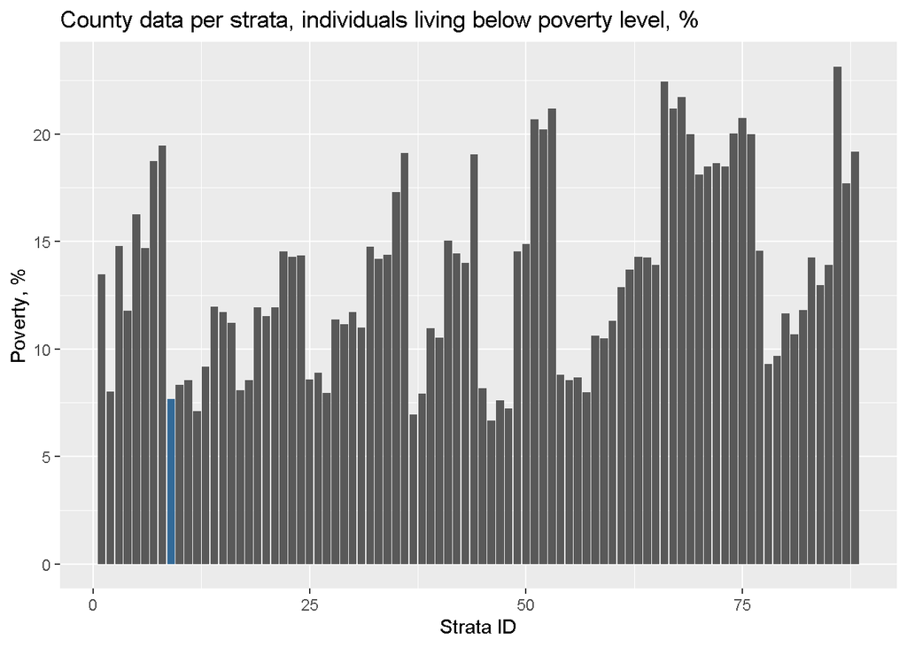

County data, population density (people per square mile)

| CHSI_County_Name | CHSI_State_Name | Population_Density |
| --- | --- | --- |
| Autauga | Alabama | 82 |
| Baldwin | Alabama | 102 |
| Barbour | Alabama | 32 |
| Bibb | Alabama | 35 |
| Blount | Alabama | 86 |
| Bullock | Alabama | 18 |

County data, average life expectancy

| CHSI_County_Name | CHSI_State_Name | ALE |
| --- | --- | --- |
| Autauga | Alabama | 74.9 |
| Baldwin | Alabama | 76.6 |
| Barbour | Alabama | 74.5 |
| Bibb | Alabama | 73.2 |
| Blount | Alabama | 76.1 |
| Bullock | Alabama | 71.9 |

Let’s left join these two data frames

Population Density and Average Life Expectancy by county

| CHSI_County_Name | CHSI_State_Name | Population_Density | ALE |
| --- | --- | --- | --- |
| Autauga | Alabama | 82 | 74.9 |
| Baldwin | Alabama | 102 | 76.6 |
| Barbour | Alabama | 32 | 74.5 |
| Bibb | Alabama | 35 | 73.2 |
| Blount | Alabama | 86 | 76.1 |
| Bullock | Alabama | 18 | 71.9 |

Let’s build a Linear Model of ALE ~ Population_Density:

```
##
## Call:
## lm(formula = ALE ~ Population_Density, data = Pop_dens_ALEdf)
##
## Residuals:
##     Min      1Q  Median      3Q     Max
## -9.7148 -1.3198  0.1846  1.3852  4.9853
##
## Coefficients:
##                     Estimate Std. Error  t value Pr(>|t|)
## (Intercept)        7.631e+01  3.603e-02 2117.889   <2e-16 ***
## Population_Density 3.020e-05  2.093e-05    1.443    0.149
## ---
## Signif. codes:  0 '***' 0.001 '**' 0.01 '*' 0.05 '.' 0.1 ' ' 1
##
## Residual standard error: 1.997 on 3136 degrees of freedom
## Multiple R-squared:  0.0006634,  Adjusted R-squared:  0.0003447
## F-statistic: 2.082 on 1 and 3136 DF,  p-value: 0.1492
```

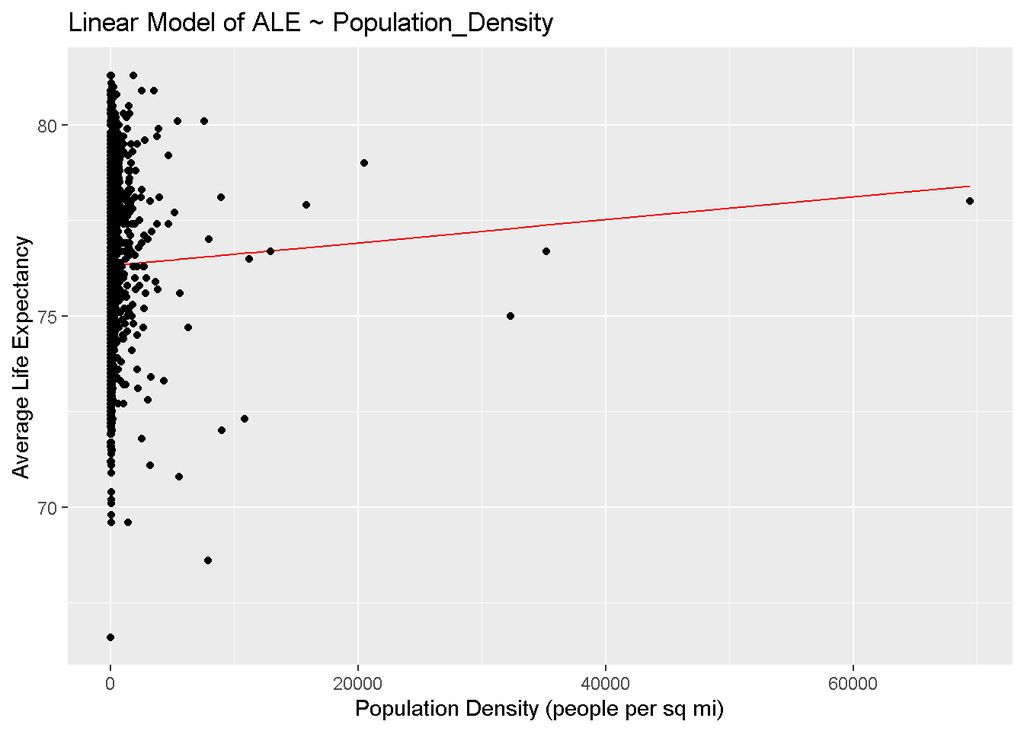

Bibliography:

1. The County Health Rankings & Roadmaps program. (August 30, 2017). Peer Counties Tool.

Retrieved 30 April 2020, from https://www.countyhealthrankings.org/resources/peer-counties-tool

2. The County Health Rankings & Roadmaps program. (2020). New Jersey Rankings Data.

Retrieved 30 April 2020, from https://www.countyhealthrankings.org/app/new-jersey/2020/downloads

3. U.S. Government’s open data. (February 26, 2020). Community Health Status Indicators (CHSI) to Combat Obesity, Heart Disease and Cancer.

Retrieved 30 April 2020, from https://catalog.data.gov/dataset/community-health-status-indicators-chsi-to-combat-obesity-heart-disease-and-cancer